# La magia del análisis de componentes principales

Giovany Babativa

2020-10-09

Con frecuencia observo que diferentes personas se interesan por el análisis de los datos, lo cual me genera bastante satisfación. Sin embargo, no deja de preocuparme que muchos de ellos no tienen una preparación previa que esté orientada al manejo de los mismos y con sorpresa, a veces, veo en algunos grupos que sigo en las redes sociales (especialmente en facebook) que sugieren de forma equivocada el uso de ciertas técnicas, como el análisis de componentes principales, pero quedo aún más precupado cuando observo que muchos apoyan el mal uso de la misma a partir de la cantidad de *likes* que genera el comentario. Dado que responder apropiadamente en un comentario no lo veo tan práctico y se quedará solo en eso, decidí realizar esta entrada y tratar de explicar algunos enfoques de esta técnica de análisis.

La técnica de análisis de componentes principales, que en adelante la denominaré PCA por sus siglas en inglés, cuenta con diferentes enfoques y variantes, tanto así que existen libros completos para abordarla (ver [Jolliffe (2010)](https://www.springer.com/gp/book/9780387954424)) por lo que abordar todos los temas en una sola entrada es dificil, pero trataré de ser lo más pedagógico y tocar los aspectos más relevantes sin dejar de lado la rigurosidad. No es necesario que sepa todo sobre algebra lineal o saber calcular de forma manual los vectores y valores propios de una matriz (aunque le sería muy útil para comprender varios conceptos en profundidad), pero si es necesario que conozca las operaciones básicas entre matrices.

De acuerdo con Jolliffe (2010), esta es una técnica muy utilizada, de hecho en la Web of Science se identifican más de 2000 artículos publicados en solo los años 1999 y 2000, que incluyen la frase *“principal component analysis”* en sus título, resumen o palabras clave. Estas referencias además muestran la gran variedad de áreas en que la técnica de PCA es aplicada, estos libros o artículos incluyen aplicaciones en biología, agricultura, química, sicología, demografía, ecología, genética, economía, y muchas más. Luego de esto, es posible que esto se incrementara dadas las extensiones que surgieron como el *Sparse PCA*, *NMF* y la *descomposición de tensores* que pueden llegar a ser tema de otra entrada.

Considere que tiene una matriz de datos que denominaré $\mathbf{X}$ compuesta por variables *continuas* $\mathbf{x}_1, \ldots, \mathbf{x}_p$, donde cada $\mathbf{x}_i$ es un vector de $n$ entradas. ¡Parece difícil!, ¿no?, pues esto no es más que notación, veamos esto con un ejemplo:

[output not shown]

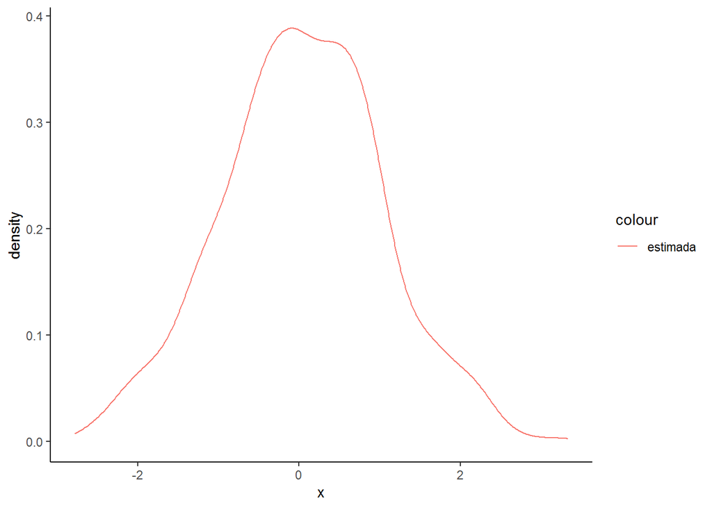

```r
library(ggplot2)

df <- data.frame( x = rnorm(1000))

g1 <- ggplot(df, aes(x)) +
  geom_density(aes(color = "estimada"), key_glyph = "path") + theme_classic()
g1
```

Hace poco encontré que la versión `3.3.2` del paquete `ggplot2` permite graficar una función. El usuario puede ingresar la sintaxis de la fórmula o citar el nombre de alguna función de probabilidad conocida. Por ejemplo, en el caso anterior se agregaría la distribución teórica de la siguiente manera

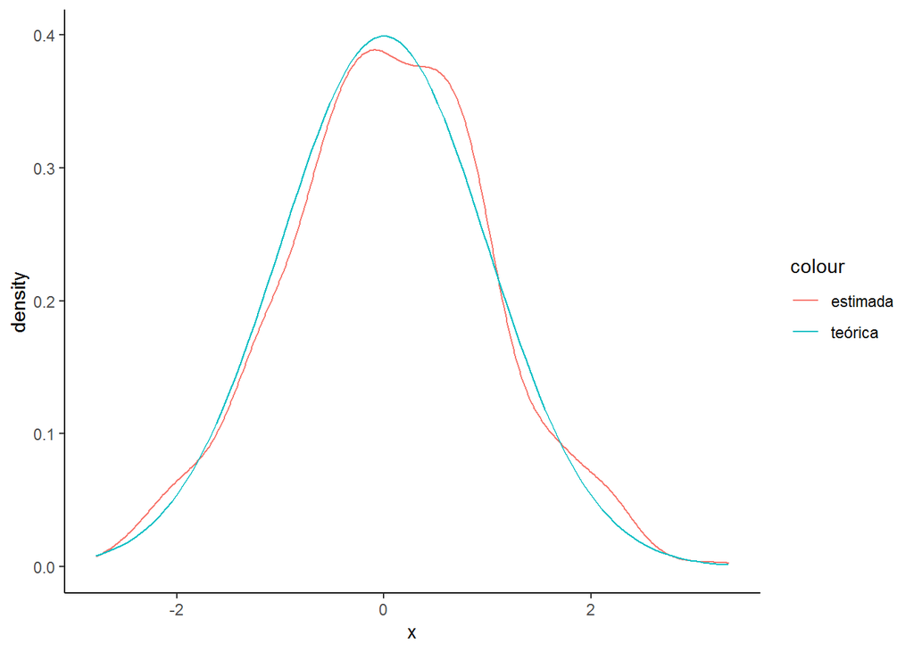

```r
g2 <- g1 +
      geom_function(aes(color = "teórica"), fun = dnorm)
g2
```

Para dar otro ejemplo, considere una distribución chi-cuadrado con 5 grados de libertad, en este caso se establecen los valores para `x` en el rango de 0 a 30. Adicionalmente, se debe agregar una tilde (`~`) después del igual (`=`) y la variable debe estar antecedida por un punto `.x`.

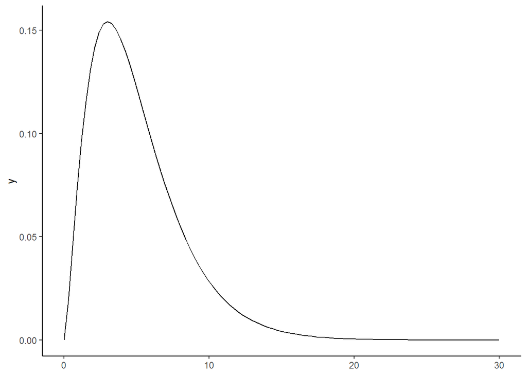

```r
ggplot() +
  xlim(0, 30) +
  geom_function(fun =~ dchisq(.x, df = 5)) + theme_classic()
```

Finalmente, usted puede escribir la sintaxis de cualquier función, si lo prefiere puede usar directamente la fdp, así:

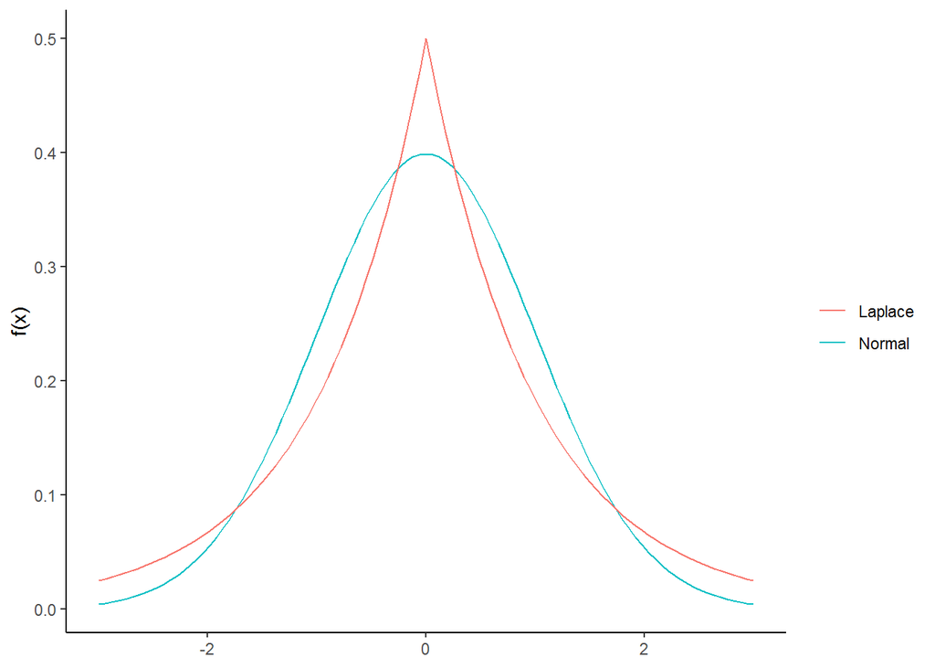

```r
ggplot() +
   xlim(-3, 3) +
   geom_function(
     aes(color = "Normal"),
     fun =~ 1/sqrt(2 * pi) * exp(-.x^2/2)
     ) +
   geom_function(
     aes(color = "Laplace"),
     fun =~ 1/2 * exp(-abs(.x))
   ) + theme_classic() +
  ylab("f(x)") + theme(legend.title = element_blank())
```

Por supuesto, puede usarlo en casos que no tienen que ver con probabilidad

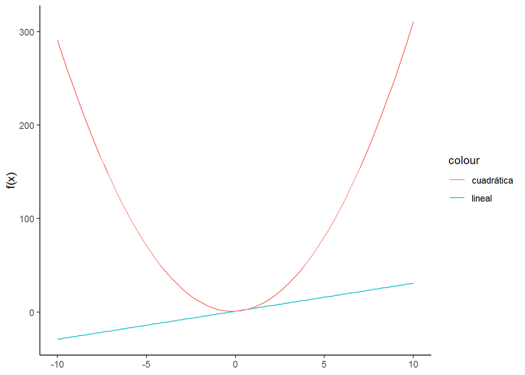

```r
ggplot() +
  xlim(-10, 10) +
  geom_function(aes(color = "lineal"),
    fun =~ 3*.x + 1
    ) +
  geom_function(aes(color = "cuadrática"),
    fun =~ 3*.x^2 + .x + 1
    ) + ylab("f(x)") + theme_classic()
```